#### New to Plotly?

Plotly's Python library is free and open source! [Get started](https://plotly.com/python/getting-started/) by downloading the client and [reading the primer](https://plotly.com/python/getting-started/).  
You can set up Plotly to work in [online](https://plotly.com/python/getting-started/#initialization-for-online-plotting) or [offline](https://plotly.com/python/getting-started/#initialization-for-offline-plotting) mode, or in [jupyter notebooks](https://plotly.com/python/getting-started/#start-plotting-online).  
We also have a quick-reference [cheatsheet](https://images.plot.ly/plotly-documentation/images/python_cheat_sheet.pdf) (new!) to help you get started!

#### Creating a Plotly Grid

You can instantiate a grid with data by either uploading tabular data to Plotly or by creating a Plotly `grid` using the API. To upload the grid we will use `plotly.plotly.grid_ops.upload()`. It takes the following arguments:

- `grid` (Grid Object): the actual grid object that you are uploading.
- `filename` (str): name of the grid in your plotly account,
- `world_readable` (bool): if `True`, the grid is `public` and can be viewed by anyone in your files. If `False`, it is private and can only be viewed by you.
- `auto_open` (bool): if determines if the grid is opened in the browser or not.

You can run `help(py.grid_ops.upload)` for a more detailed description of these and all the arguments.

```python
import plotly
import plotly.plotly as py
import plotly.tools as tls
import plotly.graph_objs as go
from plotly.grid_objs import Column, Grid

from datetime import datetime as dt
import numpy as np
from IPython.display import Image

column_1 = Column(['a', 'b', 'c'], 'column 1')
column_2 = Column([1, 2, 3], 'column 2') # Tabular data can be numbers, strings, or dates
grid = Grid([column_1, column_2])
url = py.grid_ops.upload(grid,
                         filename='grid_ex_'+str(dt.now()),
                         world_readable=True,
                         auto_open=False)
print(url)
```

```
https://plotly.com/~chelsea_lyn/17398/
```

#### View and Share your Grid

You can view your newly created grid at the `url`:

[figure not shown]

```python
Image('view_grid_url.png')
```

You are also able to view the grid in your list of files inside your [organize folder](https://plotly.com/organize).

#### Upload Dataframes to Plotly

Along with uploading a grid, you can upload a Dataframe as well as convert it to raw data as a grid:

```python
import plotly.plotly as py
import plotly.figure_factory as ff

import pandas as pd

df = pd.read_csv('https://raw.githubusercontent.com/plotly/datasets/master/2014_apple_stock.csv')
df_head = df.head()
table = ff.create_table(df_head)
py.iplot(table, filename='dataframe_ex_preview')
```

[interactive chart not shown]

```python
grid = Grid([Column(df[column_name], column_name) for column_name in df.columns])
url = py.grid_ops.upload(grid, filename='dataframe_ex_'+str(dt.now()), world_readable=True, auto_open=True)
print(url)
```

```
https://plotly.com/~chelsea_lyn/17399/
```

#### Making Graphs from Grids

Plotly graphs are usually described with data embedded in them. For example, here we place `x` and `y` data directly into our `Histogram2dContour` object:

```python
x = np.random.randn(1000)
y = np.random.randn(1000) + 1

data = [
    go.Histogram2dContour(
        x=x,
        y=y
    )
]

py.iplot(data, filename='Example 2D Histogram Contour')
```

[interactive chart not shown]

We can also create graphs based off of references to columns of grids. Here, we'll upload several `column`s to our Plotly account:

```python
column_1 = Column(np.random.randn(1000), 'column 1')
column_2 = Column(np.random.randn(1000)+1, 'column 2')
column_3 = Column(np.random.randn(1000)+2, 'column 3')
column_4 = Column(np.random.randn(1000)+3, 'column 4')

grid = Grid([column_1, column_2, column_3, column_4])
url = py.grid_ops.upload(grid, filename='randn_int_offset_'+str(dt.now()))
print(url)
```

```
https://plotly.com/~chelsea_lyn/17400/
```

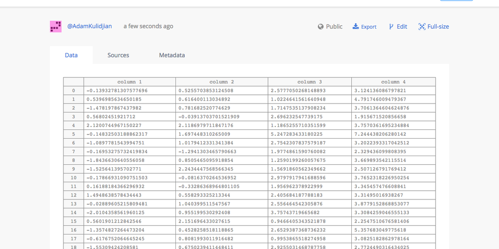

```python
Image('rand_int_histogram_view.png')
```

Instead of placing data into `x` and `y`, we'll place our Grid columns into `xsrc` and `ysrc`:

```python
data = [
    go.Histogram2dContour(
        xsrc=grid[0],
        ysrc=grid[1]
    )
]

py.iplot(data, filename='2D Contour from Grid Data')
```

[interactive chart not shown]

#### Attaching Meta Data to Grids

In [Chart Studio Enterprise](https://plotly.com/product/enterprise/), you can upload and assign free-form JSON `metadata` to any grid object. This means that you can keep all of your raw data in one place, under one grid.

If you update the original data source, in the workspace or with our API, all of the graphs that are sourced from it will be updated as well. You can make multiple graphs from a single Grid and you can make a graph from multiple grids. You can also add rows and columns to existing grids programatically.

```python
meta = {
    "Month": "November",
    "Experiment ID": "d3kbd",
    "Operator": "James Murphy",
    "Initial Conditions": {
          "Voltage": 5.5
    }
}

grid_url = py.grid_ops.upload(grid, filename='grid_with_metadata_'+str(dt.now()), meta=meta)
print(url)
```

```
https://plotly.com/~chelsea_lyn/17400/
```

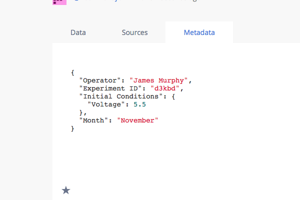

```python
Image('metadata_view.png')
```

#### Reference

```python
help(py.grid_ops)
```

````
Help on class grid_ops in module plotly.plotly.plotly:

class grid_ops
 |  Interface to Plotly's Grid API.
 |  Plotly Grids are Plotly's tabular data object, rendered
 |  in an online spreadsheet. Plotly graphs can be made from
 |  references of columns of Plotly grid objects. Free-form
 |  JSON Metadata can be saved with Plotly grids.
 |  To create a Plotly grid in your Plotly account from Python,
 |  see `grid_ops.upload`.
 |  To add rows or columns to an existing Plotly grid, see
 |  `grid_ops.append_rows` and `grid_ops.append_columns`
 |  respectively.
 |  To delete one of your grid objects, see `grid_ops.delete`.
 |  Class methods defined here:
 |  append_columns(cls, columns, grid=None, grid_url=None) from __builtin__.classobj
 |      Append columns to a Plotly grid.
 |      `columns` is an iterable of plotly.grid_objs.Column objects
 |      and only one of `grid` and `grid_url` needs to specified.
 |      `grid` is a ploty.grid_objs.Grid object that has already been
 |      uploaded to plotly with the grid_ops.upload method.
 |      `grid_url` is a unique URL of a `grid` in your plotly account.
 |      Usage example 1: Upload a grid to Plotly, and then append a column
 |      ```
 |      from plotly.grid_objs import Grid, Column
 |      import plotly.plotly as py
 |      column_1 = Column([1, 2, 3], 'time')
 |      grid = Grid([column_1])
 |      py.grid_ops.upload(grid, 'time vs voltage')
 |      # append a column to the grid
 |      column_2 = Column([4, 2, 5], 'voltage')
 |      py.grid_ops.append_columns([column_2], grid=grid)
 |      ```
 |      Usage example 2: Append a column to a grid that already exists on
 |                       Plotly
 |      ```
 |      from plotly.grid_objs import Grid, Column
 |      import plotly.plotly as py
 |      grid_url = 'https://plotly.com/~chris/3143'
 |      column_1 = Column([1, 2, 3], 'time')
````

[output cut: 95 more lines]

````
 |      from plotly.grid_objs import Grid, Column
 |      from plotly.graph_objs import Scatter
 |      # Upload a grid
 |      column_1 = Column([1, 2, 3], 'time')
 |      column_2 = Column([4, 2, 5], 'voltage')
 |      grid = Grid([column_1, column_2])
 |      py.grid_ops.upload(grid, 'time vs voltage')
 |      # Build a Plotly graph object sourced from the
 |      # grid's columns
 |      trace = Scatter(xsrc=grid[0], ysrc=grid[1])
 |      py.plot([trace], filename='graph from grid')
 |      ```
 |  ----------------------------------------------------------------------
 |  Static methods defined here:
 |  ensure_uploaded(fid)
````